# UNICEF Assignment

Maternal Mortality & Development: A Global Perspective

Author

Rakshith Raviprasad Naik - 42683

Published

04-27-2025

## Report Summary

This report examines global trends in maternal mortality from 2000 to 2020, showing a general decline but highlighting significant regional disparities. While Sub-Saharan Africa continues to experience the highest mortality rates, regions like Asia and Europe have made notable progress. These differences underscore the ongoing need for targeted global health initiatives to address gaps in maternal care.

- Data for this analysis was sourced from **UNICEF**
- Tableau Version of this Report: [Click Here](https://public.tableau.com/app/profile/rakshith.raviprasad.naik/viz/MaternalMortality_17430243784790/Dashboard)
- The color palette of red and green is used for better visual understanding.

## Key Highlights

- **Global Progress:** Maternal mortality rates declined globally from 2000 to 2020, reflecting improvements in healthcare system.
- **Regional Disparities:** Sub-Saharan Africa still has the highest maternal mortality rates, while Europe and parts of Asia show significant progress.
- **Country-Specific Trends:** Some countries made notable advances, while others saw little improvement, highlighting inequality in healthcare access.
- **Urgent Focus Areas:** Continued efforts are crucial to meet global health goals, especially in low-income regions.

## The Story of Maternal Mortality Rate and its Relationship with GDP Per Capita

## World Statistics

The visualisations provide an insightful overview of maternal mortality trends worldwide (2000–2020), revealing major regional differences and highlighting areas of progress and concern.

## World Maternal Mortality Ratio (2020) Map

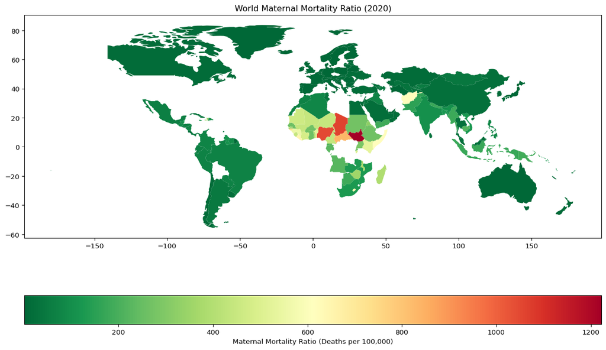

## Top 10 Countries by Maternal Mortality (2020)

This bar chart displays the top 10 countries with the highest maternal mortality rates in 2020. These countries face significant maternal health challenges, underscoring the need for urgent improvements in healthcare systems.

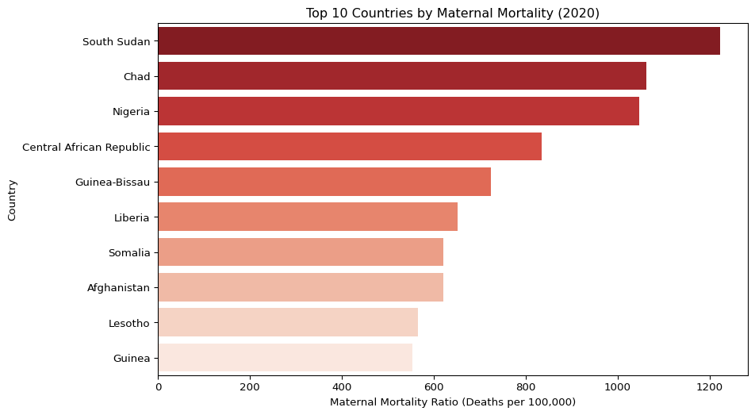

## GDP vs Maternal Mortality Ratio Scatter Plot (2000–2020)

The scatter plot reveals a strong negative correlation between GDP per capita and maternal mortality: wealthier nations consistently report lower MMRs. Regions like Europe and East Asia cluster towards high GDP and low MMR, while Sub-Saharan African nations dominate the low GDP and high MMR. Despite economic improvements in some regions, several countries remain significantly above the global average MMR.

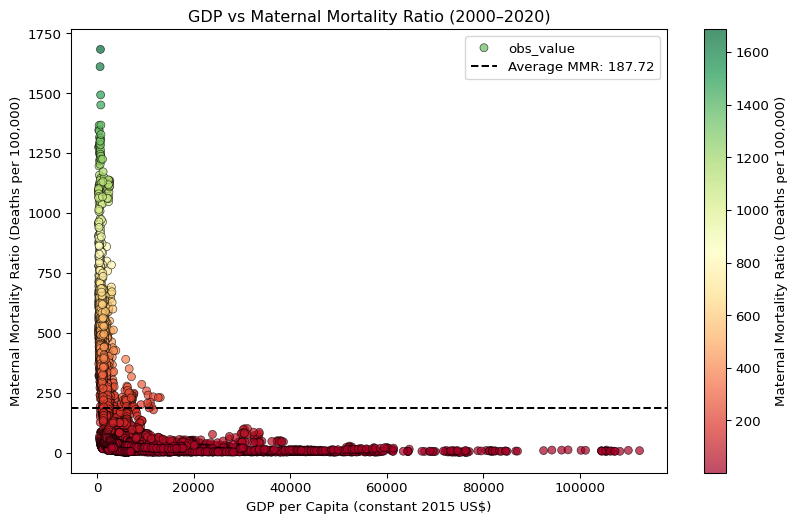

## Global Maternal Mortality Trend (2000–2020)

The global maternal mortality ratio (MMR) shows a consistent downward trend from 2000 to 2020, reflecting major improvements in healthcare access and maternal support services worldwide. While the decline is encouraging, the pace appears to slow slightly in later years, suggesting a need for renewed efforts. This trend highlights the impact of international initiatives like the Sustainable Development Goals. Continued focus is essential to maintain and accelerate progress toward eliminating preventable maternal deaths.

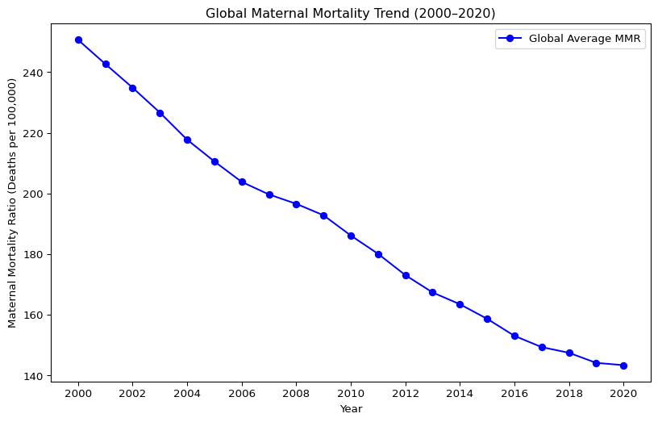

## Conclusion and Recommendations:

Maternal mortality remains a critical issue, particularly in low-income countries. While there has been global progress in reducing maternal deaths, stark disparities persist. Wealthier nations typically have lower maternal mortality, suggesting that economic development plays a significant role in improving maternal health outcomes. However, progress in lower-income countries is slower, highlighting the need for targeted interventions.

A key recommendation is to boost funding or maternal health programs in low-income countries, ensuring better access to skilled healthcare workers and emergency services. Economic development should focus on directing investments into healthcare. Finally, strengthening data collection and monitoring systems will provide valuable insights, enabling better-informed health policies and more effective interventions.